# M07 - Artrite Psoríaca

Pietro Garmatter

2024-09-23

```r
library(fpp3)
library(tidyverse)
library(RPostgres)
library(DBI)
library(GGally)
library(ggdist)
library(ggfortify)
library(MASS)
library(splines)
library(patchwork)
library(distributional)

setwd("E:/GEATS/Estimador-AIO-SUS/M07/")
load("M07.RData")

if(exists("meds.bkp")){
  meds <- meds.bkp
}

select <- dplyr::select
```

# Exploratória Soma

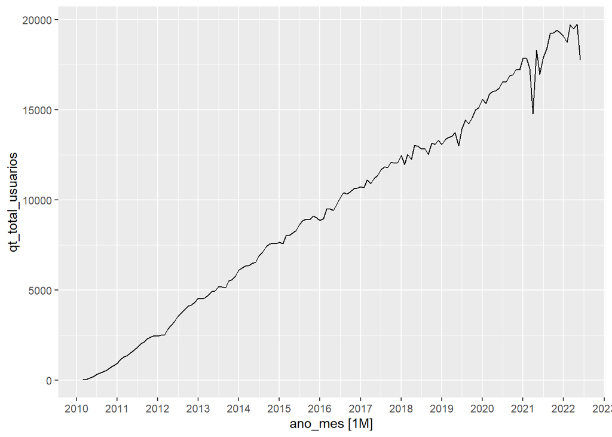

```r
autoplot(soma, qt_total_usuarios) +
  scale_x_yearmonth(date_breaks = '1 year', date_labels='%Y')
```

```r
mean(soma$qt_total_usuarios)
```

```
## [1] 9560.426
```

```r
var(soma$qt_total_usuarios)
```

```
## [1] 32718199
```

Apesar de bastantes observações, média e variância diferentes. É possível fazer análises, mas não utilizar Poisson no GLM (superdispersão).

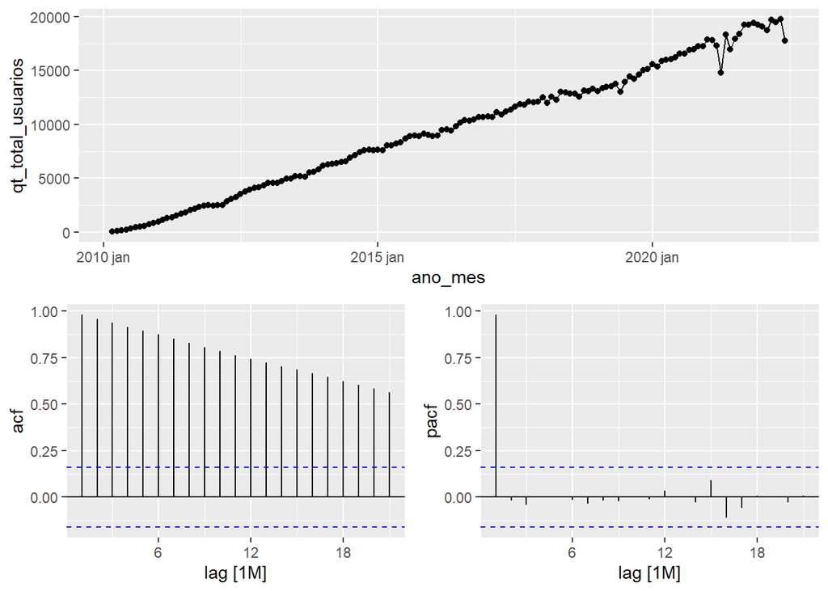

```r
gg_tsdisplay(soma, y = qt_total_usuarios, plot_type = "partial")
```

```r
(lb12 = format(ljung_box(soma$qt_total_usuarios, lag = 12)["lb_pvalue"], nsmall = 4))
```

```
## lb_pvalue
##  "0.0000"
```

```r
(lb24 = format(ljung_box(soma$qt_total_usuarios, lag = 24)["lb_pvalue"], nsmall = 4))
```

```
## lb_pvalue
##  "0.0000"
```

Os testes de Ljung-Box para 12 e 24 meses rejeita a hipótese nula de que a série seja ruído branco com valores de p iguais a 0.0000 e 0.0000.

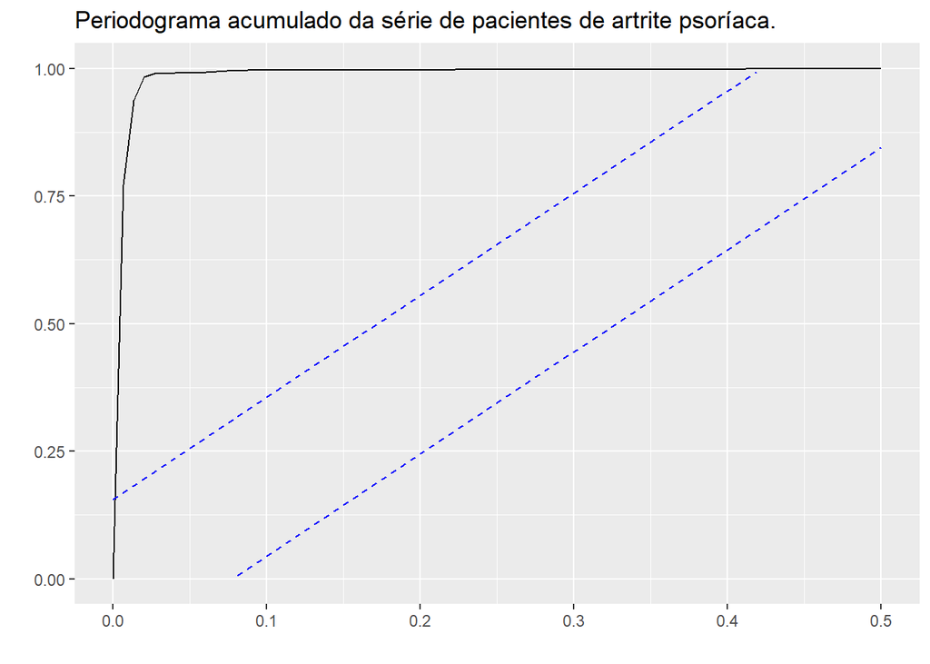

```r
ggcpgram(soma$qt_total_usuarios) +
  labs(title = 'Periodograma acumulado da série de pacientes de artrite psoríaca.')
```

Tudo indica que a soma pode ser modelada.

# Modelagem Soma

Modelo proposto ARIMA(110) com drift e sem sazonalidade.

```r
soma.treino <- soma %>% filter(ano_mes < yearmonth("2020/06"))

models <- soma.treino %>%
  model(A = ARIMA(qt_total_usuarios ~ 1 + pdq(1,1,0) + PDQ(0,0,0)),
        B = ARIMA(qt_total_usuarios),
        C = ETS(qt_total_usuarios ~ error("A") + trend("A") + season("N")),
        D = ETS(qt_total_usuarios ~ error("M") + trend("A") + season("N")),
        E = TSLM(qt_total_usuarios ~ ano_mes))

quasipoisson = glm(qt_total_usuarios ~ ano_mes, soma.treino, family = quasipoisson())

binomialneg = glm.nb(qt_total_usuarios ~ ano_mes, soma.treino)
nb.label = "F"

glance(models) %>%
  select(.model, AIC) %>%
  bind_rows(data.frame(.model = c('quasipoisson', nb.label), AIC = c(NA, AIC(binomialneg))))
```

```
## # A tibble: 7 × 2
##   .model         AIC
##   <chr>        <dbl>
## 1 A            1647.
## 2 B            1645.
## 3 C            1905.
## 4 D            2159.
## 5 E            1402.
## 6 quasipoisson   NA
## 7 F            2299.
```

Modelo E (TSLM) teve o melhor AIC seguido de B (ARIMA(0,1,1) w/ drift encontrado com stepwise) e A (ARIMA proposto).

# Análise de resíduos (soma)

```r
newdata = soma %>% filter(ano_mes >= yearmonth("2020/06"))

cast <- models %>%
  forecast(new_data = newdata)

nb.cast = predict.glm(binomialneg, newdata, type="response")
nb.mean = nb.cast #uma por mes
nb.var = var(soma$qt_total_usuarios) #var da serie ou da série predita? NESSE CASO USEI DA SERIE POIS ESTAVA DANDO P>1

size = nb.mean^2 /(nb.var - nb.mean)
prob = nb.mean / nb.var

nb.cast = fable(.model = nb.label,
                ano_mes = unique(cast$ano_mes),
                qt_total_usuarios = dist_negative_binomial(size, prob),
                mean = nb.cast,
                d1 = c(NA, diff(nb.cast)),
                response = 'qt_total_usuarios',
                distribution = 'qt_total_usuarios')
```

```
## Using `ano_mes` as index variable.
```

```r
cast <- cast %>%
  bind_rows(nb.cast)

cast %>%
  accuracy(soma,
           list(REQM = RMSE,
                winkler = winkler_score), level = 95)
```

```
## # A tibble: 6 × 4
##   .model .type   REQM winkler
##   <chr>  <chr>  <dbl>   <dbl>
## 1 A      Test    829.   5158.
## 2 B      Test    831.   5748.
## 3 C      Test    832.   5735.
## 4 D      Test   1248. 290611.
## 5 E      Test    933.  12663.
## 6 F      Test  18098. 305910.
```

O modelo proposto A (ARIMA(1,1,0) com drift) obteve as melhores métricas tanto para o ajuste de média (REQM 828.9860) quanto ao intervalo preditivo (escore 5158.454), seguido dos modelos B (ARIMA(0,1,1) com drift, REQM 831.2579) e C (Suavização exponencial de Holt, escore 5734.806). B e C tiveram desempenhos bastante próximos.

# Análise dos gráficos Soma

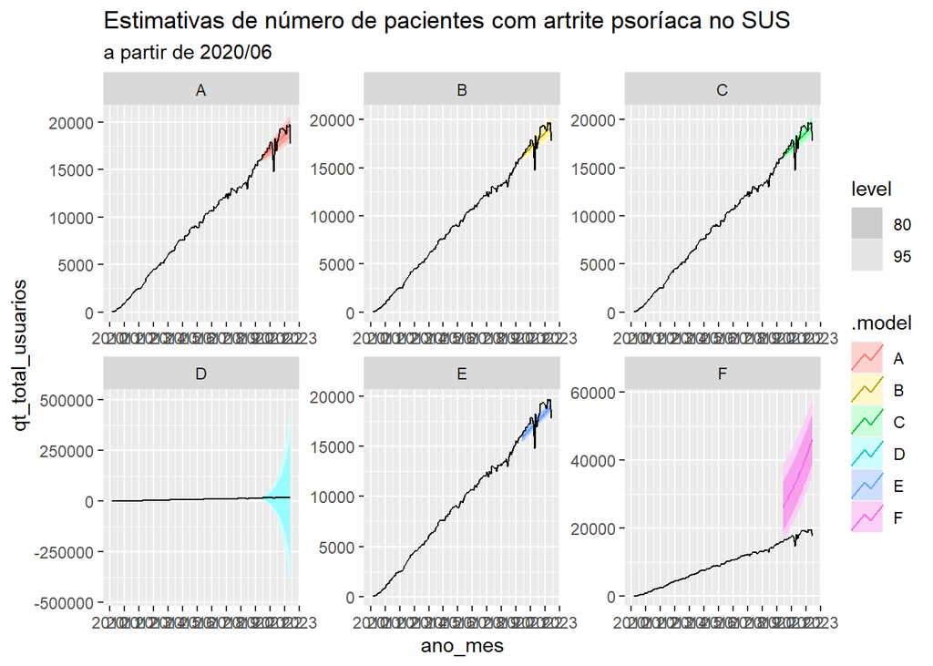

```r
cast %>%
  autoplot(soma) +
  facet_wrap(~ .model, scales = "free") +
  scale_x_yearmonth(date_breaks = '1 years', date_labels='%Y') +
  labs(title = "Estimativas de número de pacientes com artrite psoríaca no SUS",
       subtitle = "a partir de 2020/06")
```

Os três primeiros modelos, já comentados acima, tiveram predições satisfatórias. Porém, nenhum deles foi capaz de predizer a queda brusca e imprevisível observada em 2021. Dentre eles, sugere-se o uso do modelo proposto A, por ter melhores métricas no geral.

# Análises de medicamentos

```r
tratamentos %>%
  select(no_identificador, via, linha_tto, periodicidade_min, periodicidade_max, somente_adulto) %>%
  unique()
```

```
##    no_identificador       via linha_tto periodicidade_min periodicidade_max
## 1         ADAL60438 injetavel         3                14                14
## 6         CERT60438 injetavel         4                14                28
## 7         ETAN60438 injetavel         3                 7                 7
## 10        GOLI60438 injetavel         3                28                28
## 11        INFL60438 injetavel         3                56                56
## 13        LEFL60432      oral         1                 1                 1
## 14        METO60453 injetavel         1                 7                 7
## 15        METO60453      oral         1                 1                 1
## 16        SECU60469 injetavel         4                28                28
## 17        CITR60432      oral         4               0,5               0,5
##    somente_adulto
## 1               0
## 6               1
## 7               0
## 10              1
## 11              0
## 13              0
## 14              0
## 15              0
## 16              1
## 17              1
```

Existem 10 tratamentos no total nos dados.

```r
meds <- meds %>%
  mutate(key = paste(no_identificador, via, sep = '_')) %>%
  as_tsibble(key = key, index = ano_mes)
```

Como a abordagem de modelagem da diferenciada da tendência não foi satisfatória para M45, o método não foi reproduzido para outros PCDTs. Segue-se para as outras análises.

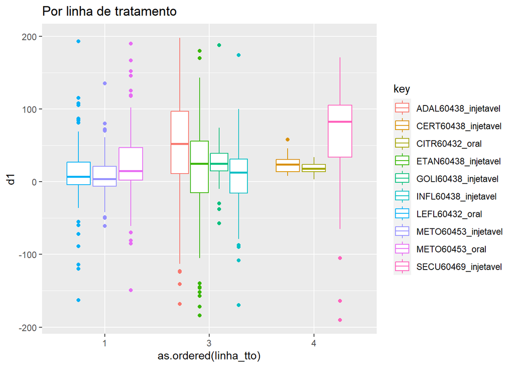

```r
# removendo diferenças maiores que +-200, pois são outliers e dificultam a visualização do restante.
meds <- meds %>% mutate(d1 = difference(qt_usuarios))

meds %>%
  filter(d1 > -200 & d1 < 200) %>%
  ggplot(aes(x = as.ordered(linha_tto), y = d1, colour = key)) +
  geom_boxplot() +
  labs(title = "Por linha de tratamento")
```

Em média, a linha de tratamento não parece influenciar diretamente a taxa de difusão de cada tecnologia. Apesar de secuquinumabe apresentar uma mediana de crescimento maior que os concorrentes, o mesmo comportamento não é observado para outros medicamentos da mesma linha de tratamento.

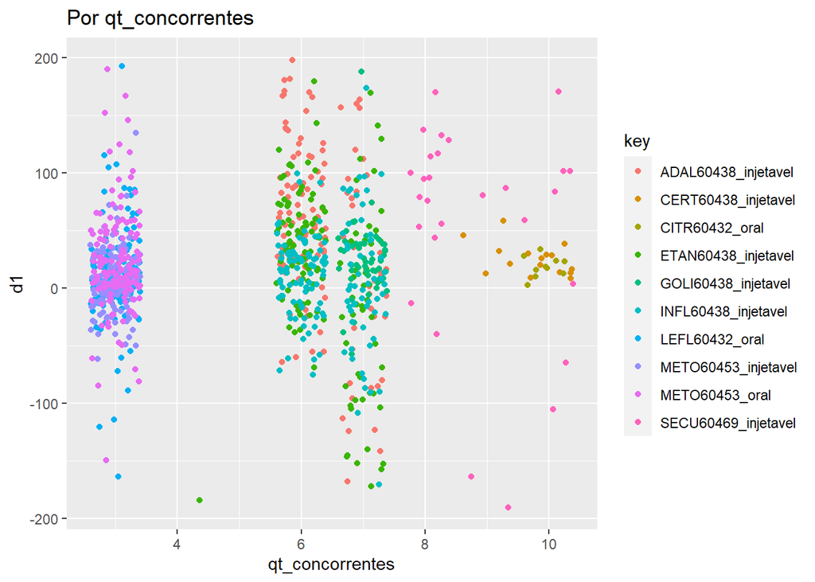

```r
meds %>%
  filter(d1 > -200 & d1 < 200) %>%
  ggplot(aes(x = qt_concorrentes, y = d1, colour = key)) +
  geom_jitter() +
  labs(title = "Por qt_concorrentes")
```

O mesmo se observa para a quantidade de concorrentes, não parecendo ser um fator determinante na média da taxa de difusão, apesar de apresentar certa variância em diferentes estágios. Possível que seja explicado pelo tempo em que as tecnologias competem. Entre 6 e 7 concorrentes, contudo, parece haver uma pequena diminuição na taxa de difusão.

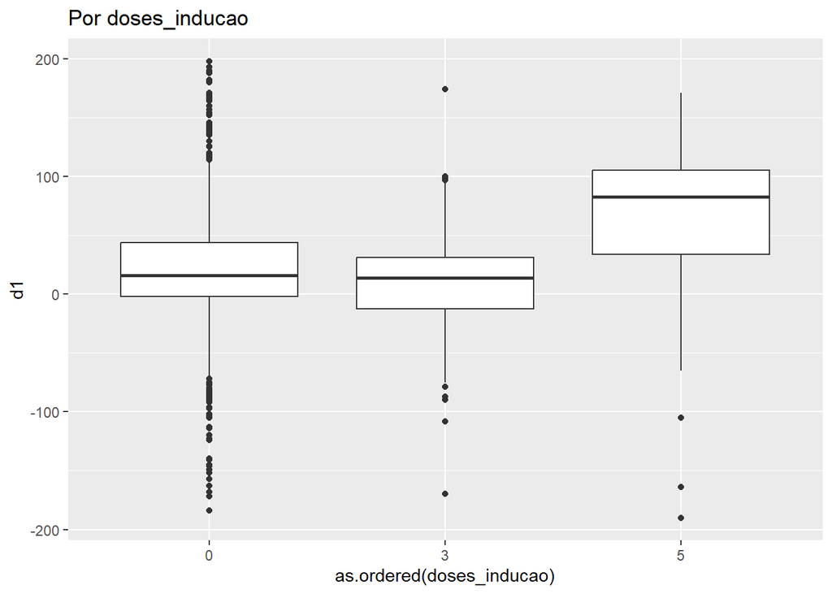

```r
meds %>%
  filter(d1 > -200 & d1 < 200) %>%
  ggplot(aes(x = as.ordered(doses_inducao), y = d1)) +
  geom_boxplot() +
  labs(title = "Por doses_inducao")
```

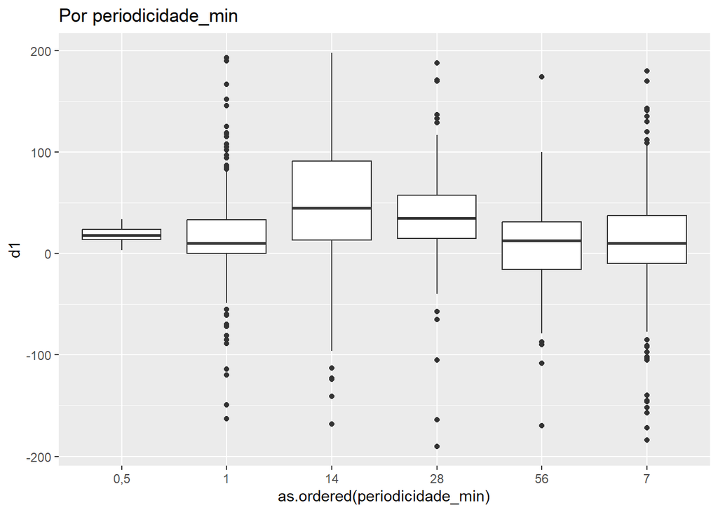

```r
meds %>%
  filter(d1 > -200 & d1 < 200) %>%
  ggplot(aes(x = as.ordered(periodicidade_min), y = d1)) +
  geom_boxplot() +
  labs(title = "Por periodicidade_min")
```

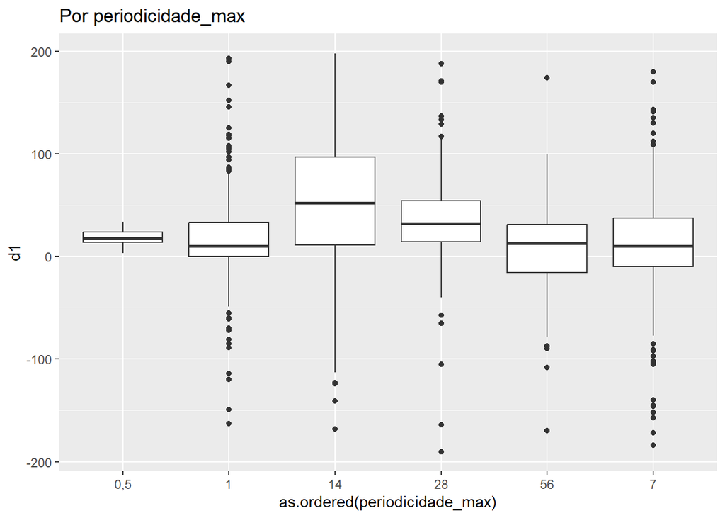

```r
meds %>%
  filter(d1 > -200 & d1 < 200) %>%
  ggplot(aes(x = as.ordered(periodicidade_max), y = d1)) +
  geom_boxplot() +
  labs(title = "Por periodicidade_max")
```

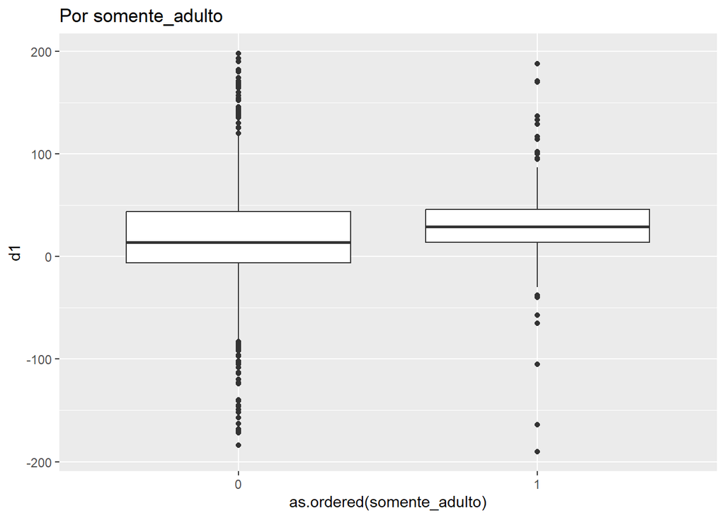

```r
meds %>%
  filter(d1 > -200 & d1 < 200) %>%
  ggplot(aes(x = as.ordered(somente_adulto), y = d1)) +
  geom_boxplot() +
  labs(title = "Por somente_adulto")
```

Nenhuma das características definidas acima parecem ter relação linear com a taxa de crescimento no número de pacientes. O número de doses de indução pode parecer ter uma relação crescente, porém somente secuquinumabe pertence à classe de 5 doses indutórias, e se destaca. As periodicidades mínima e máxima apresentam comportamentos bastante relacionados entre si.

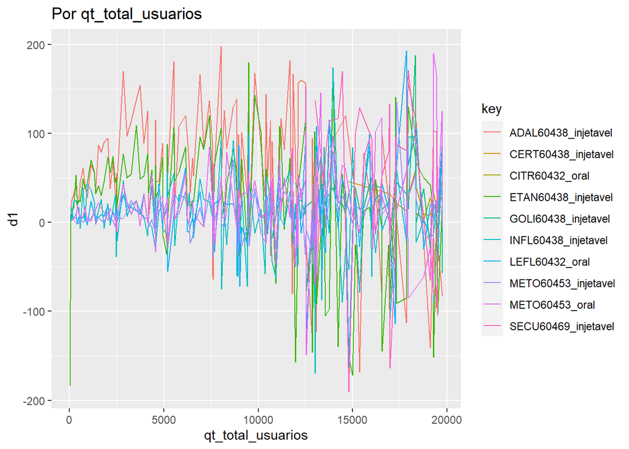

```r
meds %>%
  filter(d1 > -200 & d1 < 200) %>%
  ggplot(aes(x = qt_total_usuarios, y = d1, colour = key)) +
  geom_line() +
  labs(title = "Por qt_total_usuarios")
```

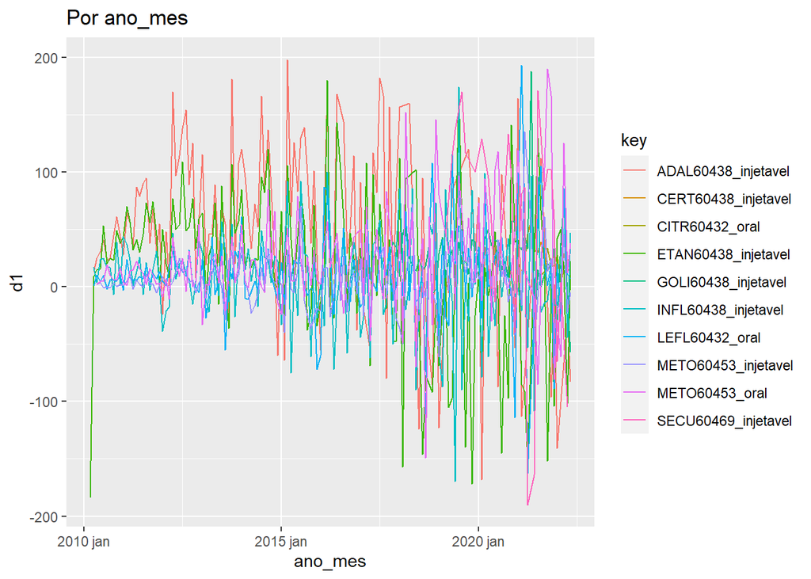

```r
meds %>%
  filter(d1 > -200 & d1 < 200) %>%
  ggplot(aes(x = ano_mes, y = d1, colour = key)) +
  geom_line() +
  labs(title = "Por ano_mes")
```

Finalmente, as séries diferenciadas parecem todas razoavelmente estacionárias na média com o aumento no número total de pacientes, bem como com o passar do tempo (altamente correlacionado com o número de pacientes total), salvo algumas observações incomuns. Observa-se também um crescimento na variância com o decorrer do tempo.

## Seguindo com a modelagem dos medicamentos

```r
for(i in unique(meds$key)) {
  print((meds %>%
           filter(key == i) %>%
           as_tibble() %>%
           select(qt_usuarios))$qt_usuarios %>%
          ggcpgram() +
          labs(title = paste("Periodograma acumulado", i)))
}
```

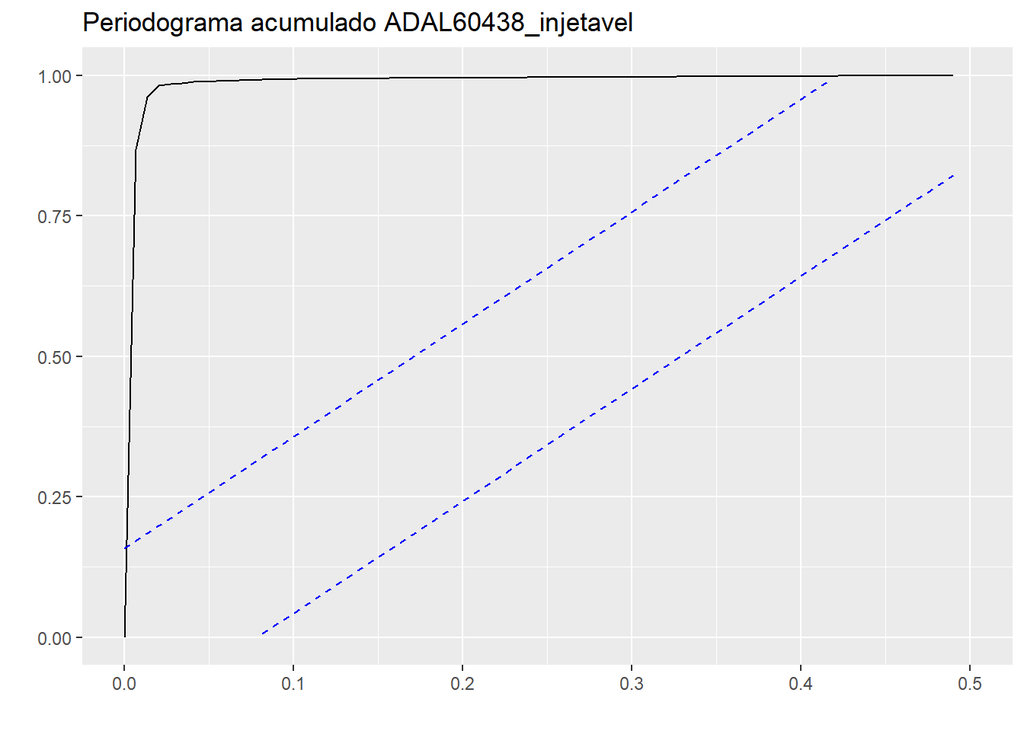

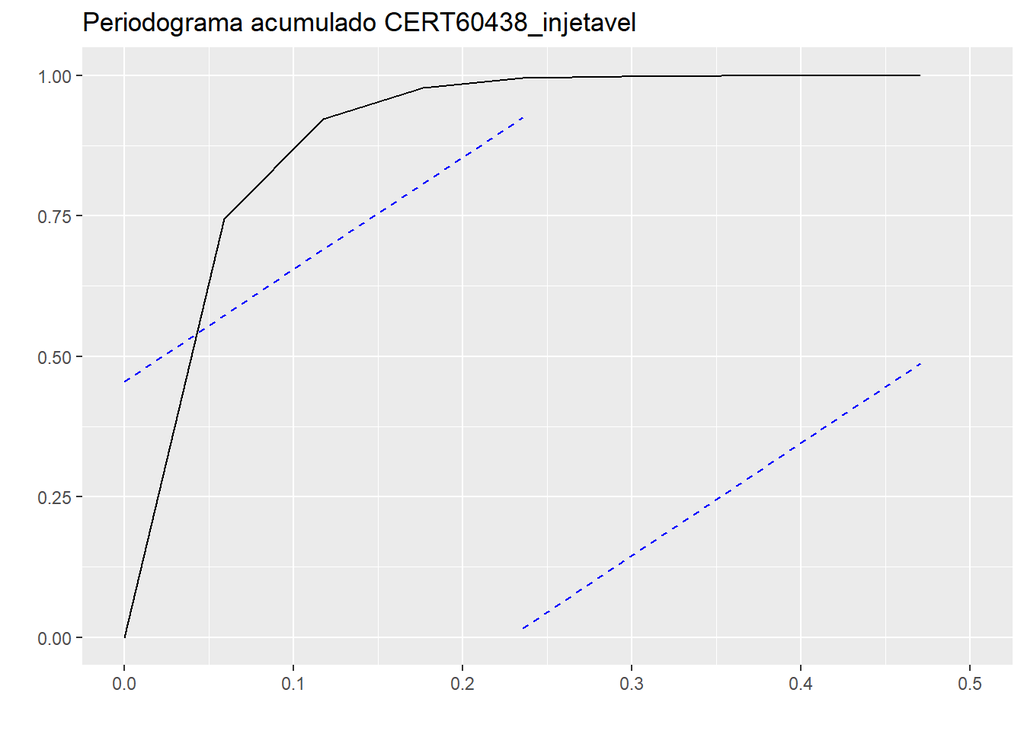

```
## `geom_line()`: Each group consists of only one observation.
## ℹ Do you need to adjust the group aesthetic?
```

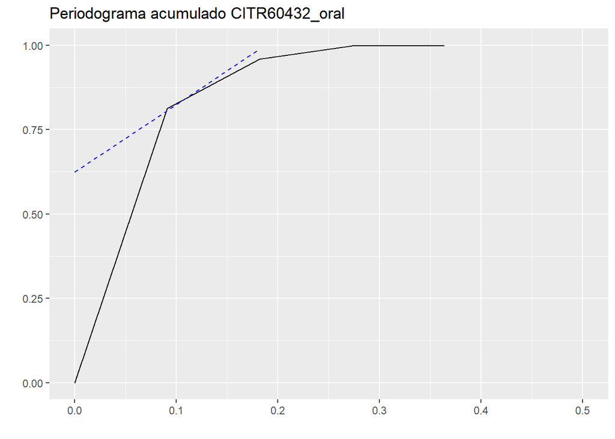

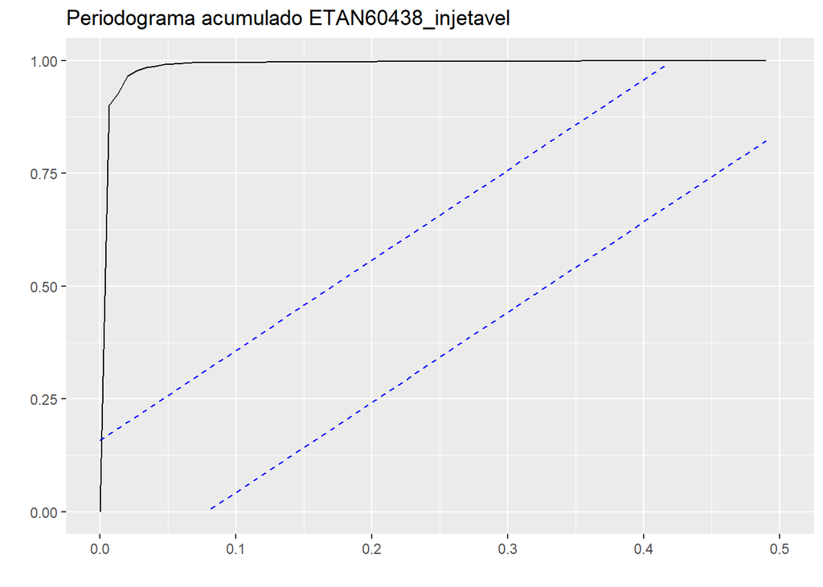

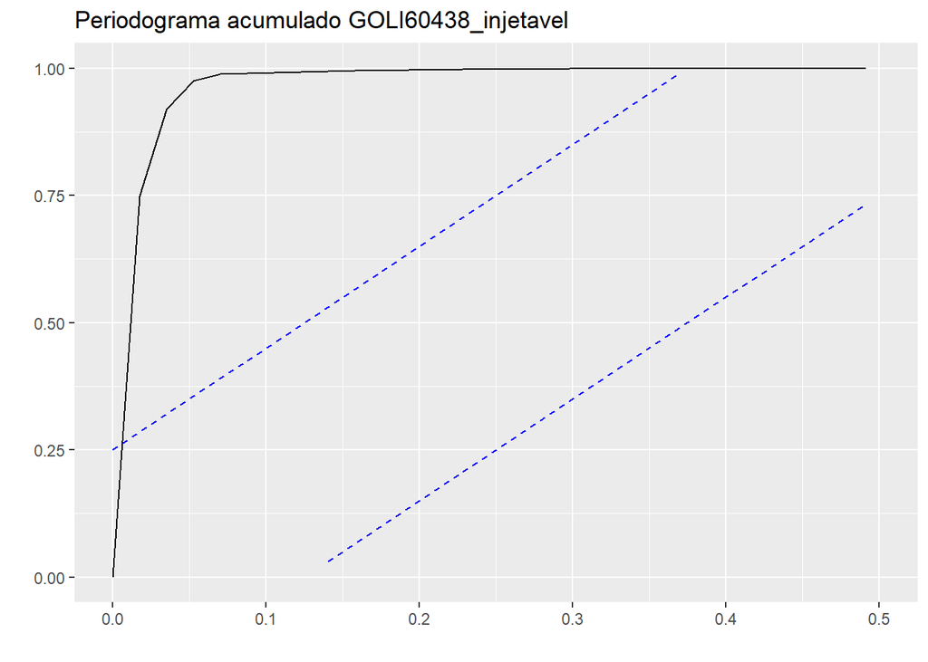

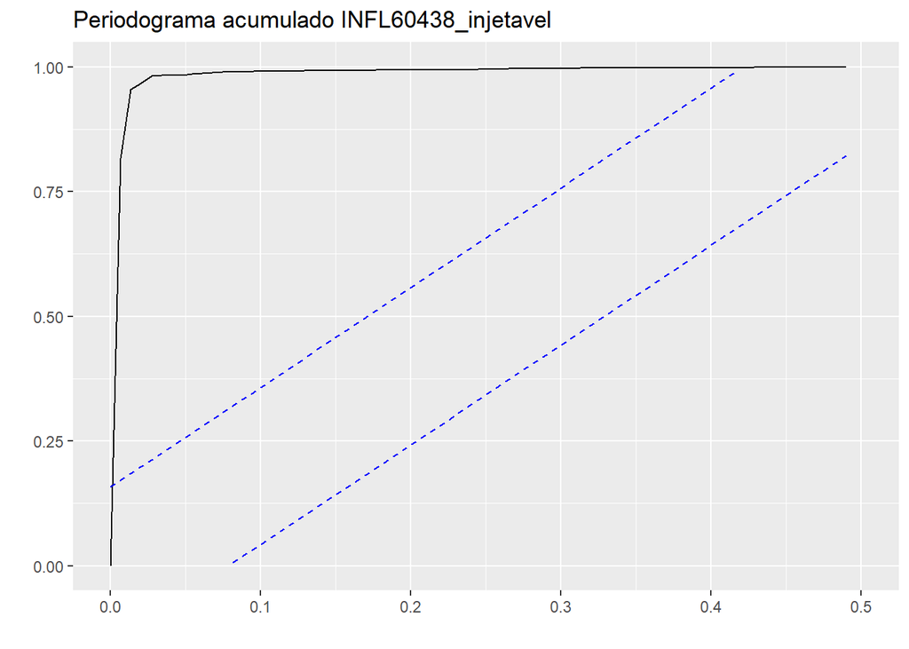

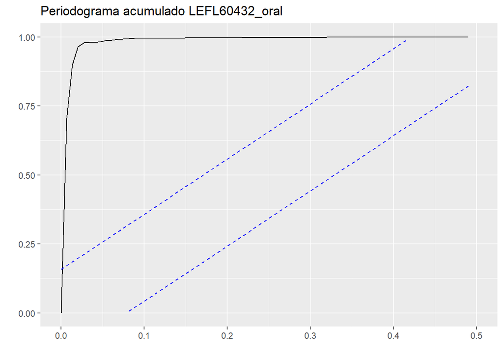

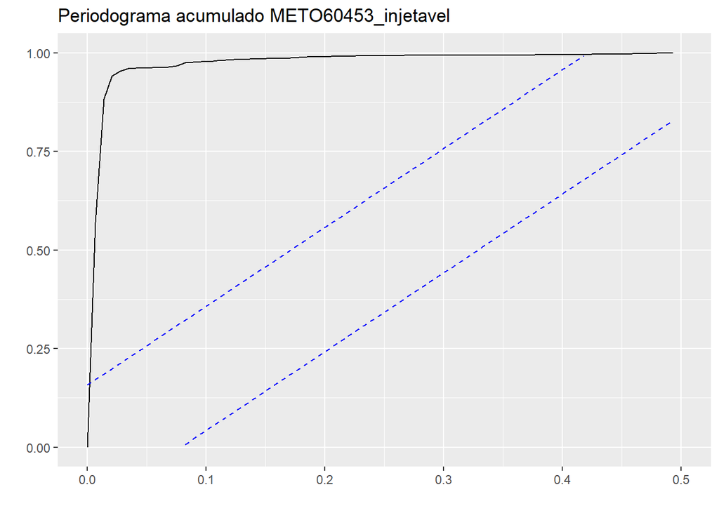

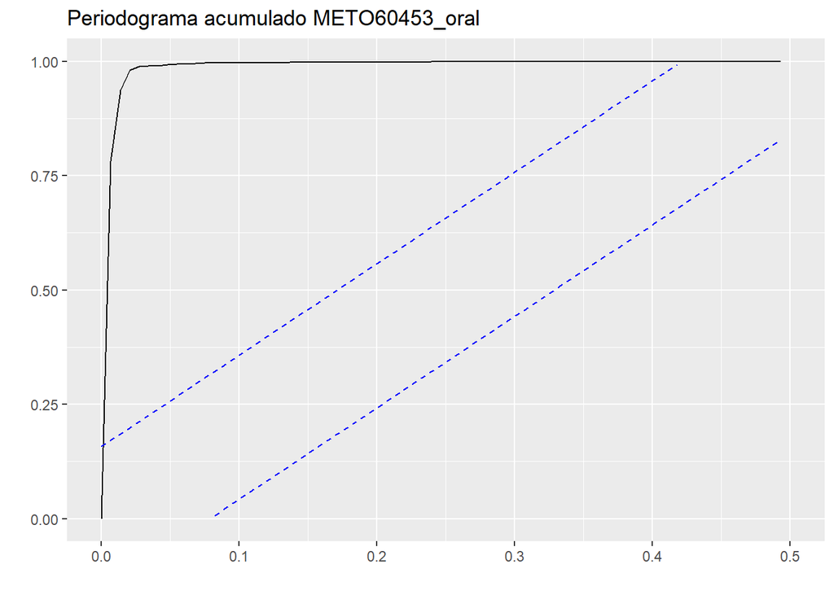

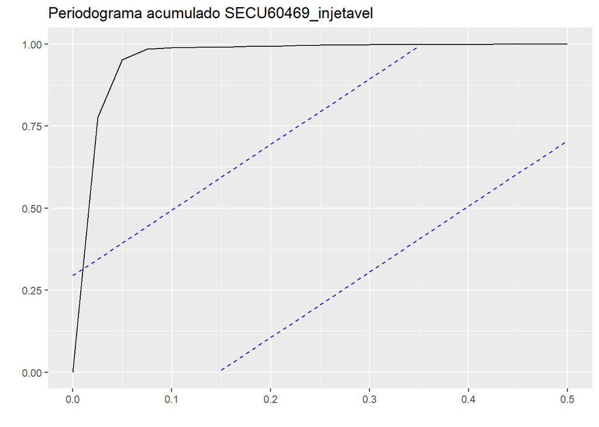

Os periodogramas acumulados de pacientes de todos os medicamentos aponta para a existência de componente sistemático a ser modelado, exceto tofacitinibe (CITR60432), que parece ser ruído branco. Confere-se com o teste Ljung-Box

```r
citr <- meds %>% filter(no_identificador == "CITR60432")
(lb12 = format(ljung_box(citr$qt_usuarios, lag = 12)["lb_pvalue"], nsmall = 4))
```

```
## lb_pvalue
##      "NA"
```

```r
(lb24 = format(ljung_box(citr$qt_usuarios, lag = 24)["lb_pvalue"], nsmall = 4))
```

```
## lb_pvalue
##      "NA"
```

```r
rm(citr)
```

Os testes Ljung-Box para 12 e 24 meses não foram possíveis. Investiga-se o porque.

```r
meds %>%
  as_tibble() %>%
  group_by(key) %>%
  summarise(inicio = min(ano_mes),
            final = max(ano_mes),
            total_meses = n())
```

```
## # A tibble: 10 × 4
##    key                   inicio    final total_meses
##    <chr>                  <mth>    <mth>       <int>
##  1 ADAL60438_injetavel 2010 mar 2022 mai         147
##  2 CERT60438_injetavel 2021 jan 2022 mai          17
##  3 CITR60432_oral      2021 jul 2022 mai          11
##  4 ETAN60438_injetavel 2010 mar 2022 mai         147
##  5 GOLI60438_injetavel 2017 set 2022 mai          57
##  6 INFL60438_injetavel 2010 mar 2022 mai         147
##  7 LEFL60432_oral      2010 mar 2022 mai         147
##  8 METO60453_injetavel 2010 abr 2022 mai         146
##  9 METO60453_oral      2010 abr 2022 mai         146
## 10 SECU60469_injetavel 2019 fev 2022 mai          40
```

Pela análise dos períodos de disponibilidade no SUS, percebe-se o motivo de não ser possível modelar tofacitinibe, bem como certolizumabe pegol. Ambos têm poucas observações nos dados, o que impede o uso das técnicas de séries temporais propostas para o estudo. Para estes dois medicamentos, o ideal é colher mais observações antes de fazer uma modelagem. Secuquinumabe pode ter o mesmo problema, por ter menos de 50 observações, porém, foi possível ajustar modelos em outros PCDTs que contavam com cerca de 40 observações sem prejuízo.

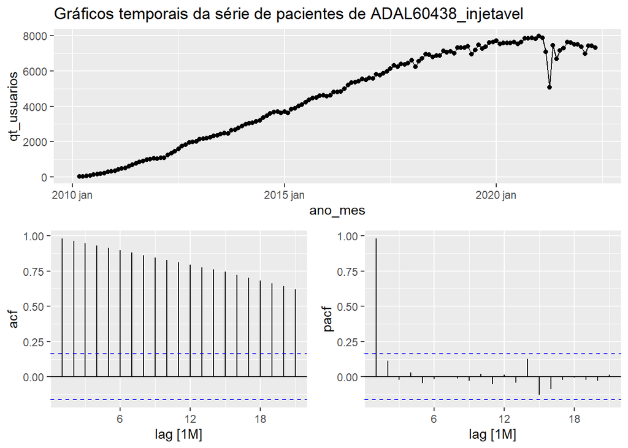

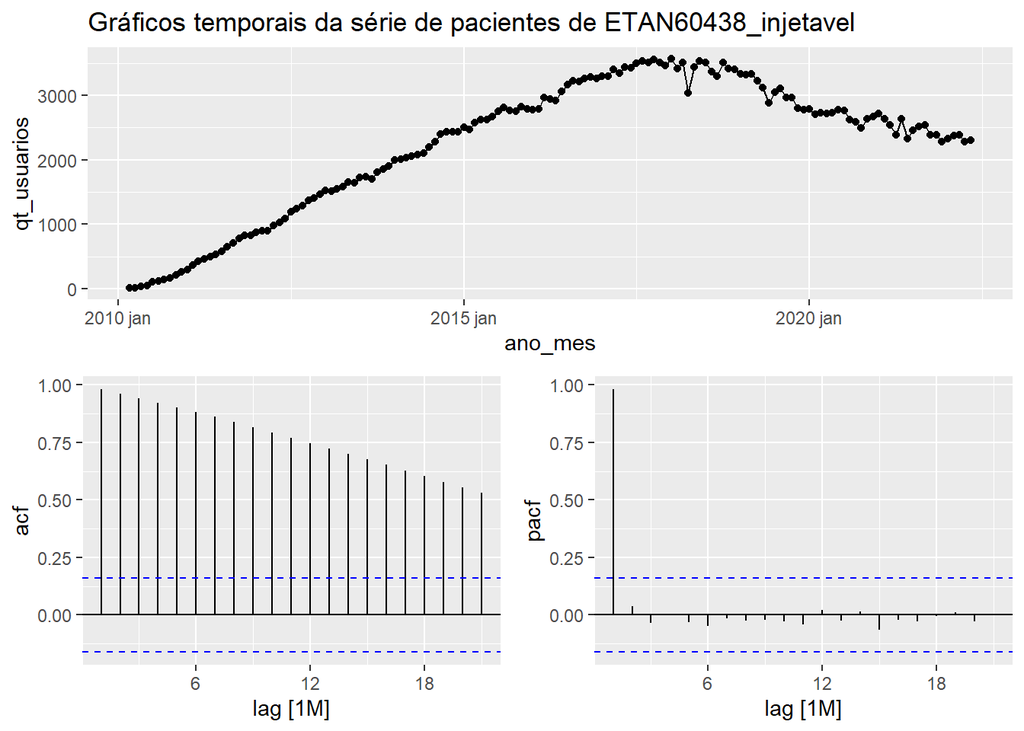

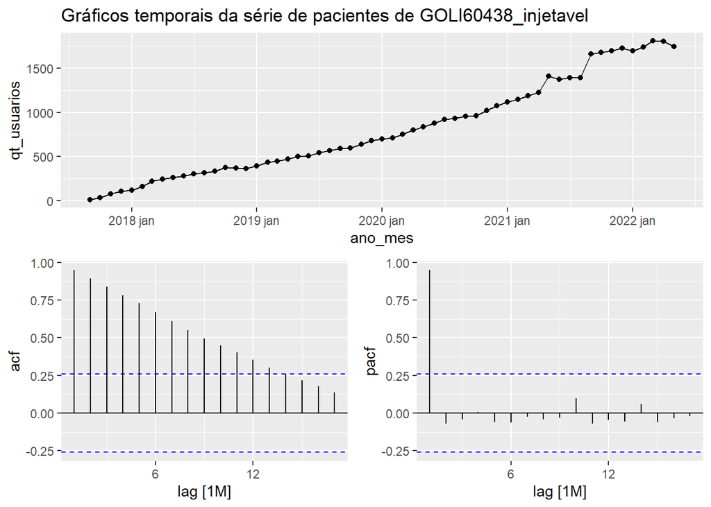

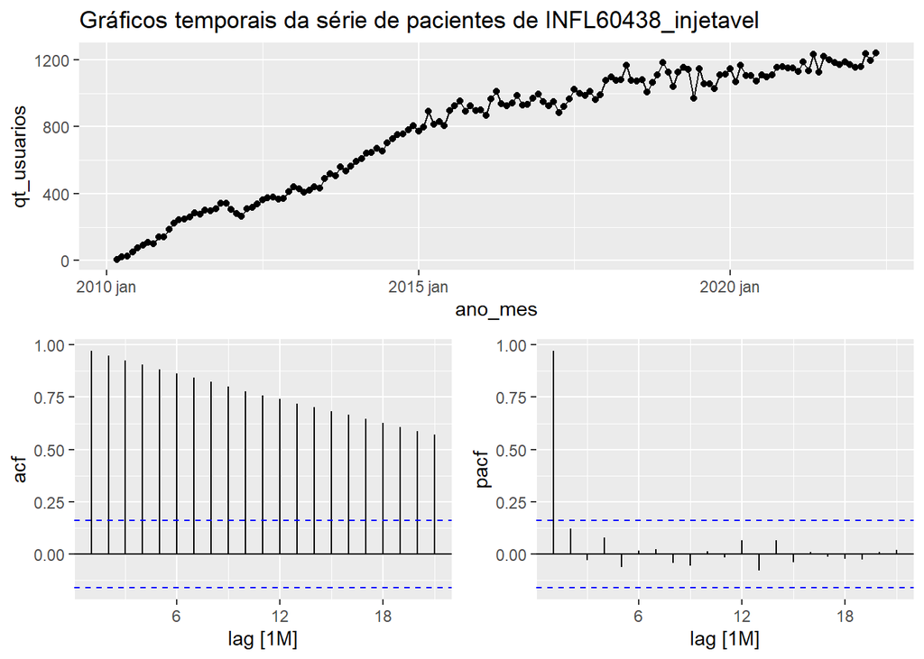

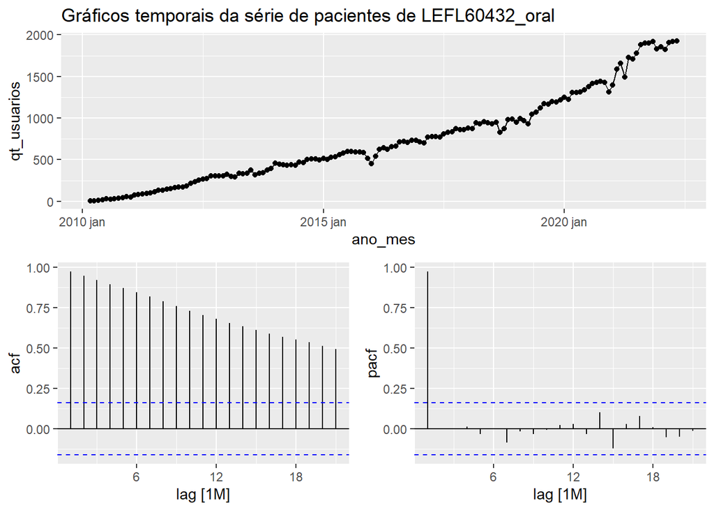

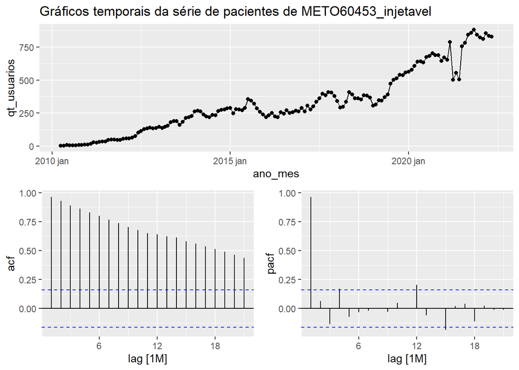

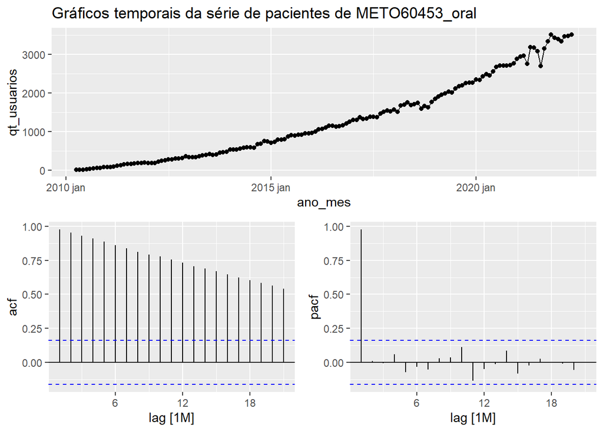

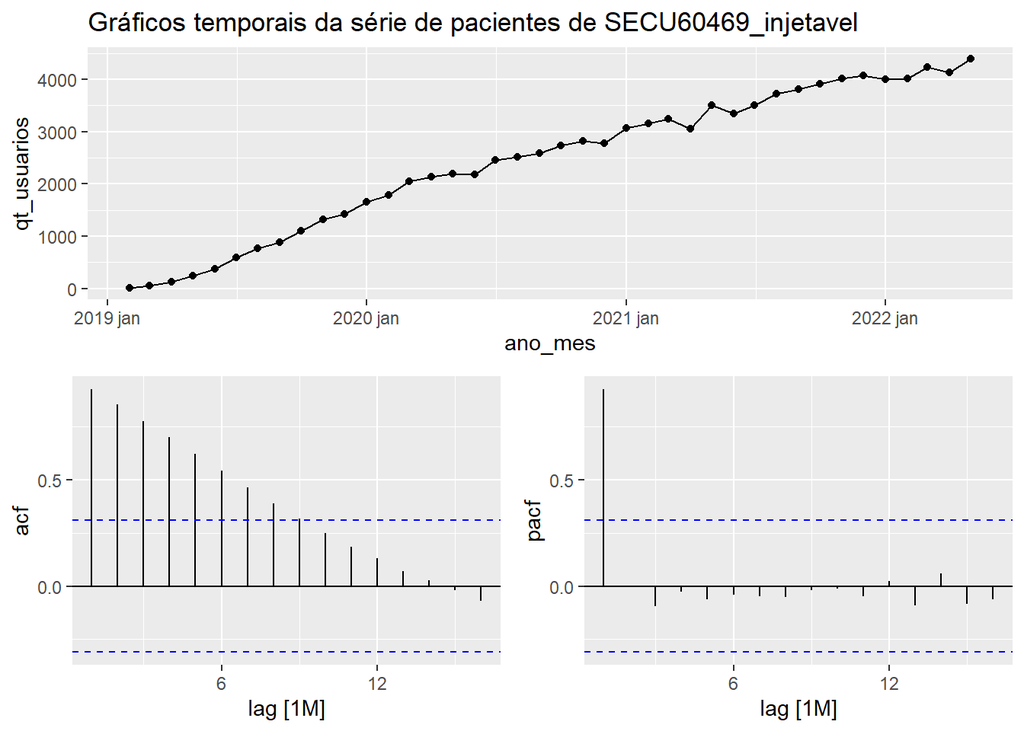

```r
# removendo os medicamentos não modelados.
meds.bkp <- meds

meds <- meds %>% filter(!(no_identificador %in% c("CERT60438", "CITR60432")))

for(i in unique(meds$key)) {
  print(
    meds %>%
      filter(key == i) %>%
      gg_tsdisplay(qt_usuarios, plot_type = "partial") +
      labs(title = paste("Gráficos temporais da série de pacientes de", i))
  )
}
```

```r
meds.treino <- meds %>% filter(ano_mes < yearmonth("2020/06")) %>% select(-d1)

meds.models <- meds.treino %>%
  model(
    A = ARIMA(qt_usuarios ~ 1 + pdq(1, 1, 0) + PDQ(0, 0, 0)),
    B = ARIMA(qt_usuarios),
    C = ARIMA(qt_usuarios ~ qt_concorrentes + qt_total_usuarios + pdq()),
    D = decomposition_model(
      STL(qt_usuarios ~ trend()),
      ARIMA(trend ~ qt_concorrentes + qt_total_usuarios),
      NAIVE(remainder)
    ),
    E = ETS(qt_usuarios ~ error("A") + trend("A") + season("N")),
    F = ETS(qt_usuarios ~ error("M") + trend("A") + season("N")),
    G = TSLM(qt_usuarios)
  )
meds.models %>%
  select(key, B:D)
```

```
## # A mable: 8 x 4
## # Key:     key [8]
##   key                                   B                                      C
##   <chr>                           <model>                                <model>
## 1 ADAL60438_inje… <ARIMA(0,1,1) w/ drift>            <LM w/ ARIMA(1,0,4) errors>
## 2 ETAN60438_inje…          <ARIMA(0,2,2)>            <LM w/ ARIMA(2,2,4) errors>
## 3 GOLI60438_inje… <ARIMA(0,1,0) w/ drift>                           <NULL model>
## 4 INFL60438_inje… <ARIMA(0,1,1) w/ drift> <LM w/ ARIMA(1,0,1)(0,0,1)[12] errors>
## 5 LEFL60432_oral  <ARIMA(0,1,2) w/ drift>            <LM w/ ARIMA(1,0,0) errors>
## 6 METO60453_inje… <ARIMA(1,1,0) w/ drift>                           <NULL model>
## 7 METO60453_oral           <ARIMA(1,2,1)>                           <NULL model>
## 8 SECU60469_inje… <ARIMA(0,1,0) w/ drift>                           <NULL model>
## # ℹ 1 more variable: D <model>
```

```r
mm.t.acc <- meds.models %>%
  accuracy(list(REQM = RMSE), level = 95) %>%
  mutate(periodo = 0, winkler = NaN) %>%
  select(-.type) %>%
  relocate(key, .model, periodo, REQM)
```

```r
# meds.models forecast accuracy 12 e 24

newdata <- meds %>% filter(ano_mes > max(meds.treino$ano_mes), ano_mes <= max(meds.treino$ano_mes) + 12)

meds.cast.12 <- meds.models %>%
  forecast(new_data = newdata)

mm.f.acc.12 <- meds.cast.12 %>%
  accuracy(meds,
           list(REQM = RMSE,
                winkler = winkler_score), level = 95) %>%
  mutate(periodo = 12) %>%
  select(-.type) %>%
  relocate(key, .model, periodo, REQM, winkler) %>%
  arrange(key, .model)

# 24
newdata <- meds %>% filter(ano_mes > max(meds.treino$ano_mes), ano_mes <= max(meds.treino$ano_mes) + 24)

meds.cast.24 <- meds.models %>%
  forecast(new_data = newdata)

mm.f.acc.24 <- meds.cast.24 %>%
  accuracy(meds,
           list(REQM = RMSE,
                winkler = winkler_score), level = 95) %>%
  mutate(periodo = 24) %>%
  select(-.type) %>%
  relocate(key, .model, periodo, REQM, winkler) %>%
  arrange(key, .model)

(mm.f.acc <- mm.t.acc %>%
    union(mm.f.acc.12) %>%
    union(mm.f.acc.24) %>%
    filter(!is.na(REQM)) %>%
    arrange(key, .model) %>%
    pivot_longer(cols = c(REQM, winkler), names_to = "metrica") %>%
    pivot_wider(names_from = periodo,
                values_from = value,
                names_prefix = "v."))
```

```
## # A tibble: 96 × 6
##    key                 .model metrica   v.0   v.12   v.24
##    <chr>               <chr>  <chr>   <dbl>  <dbl>  <dbl>
##  1 ADAL60438_injetavel A      REQM    104.   1030.  1260.
##  2 ADAL60438_injetavel A      winkler NaN   12904. 21707.
##  3 ADAL60438_injetavel B      REQM    103.   1040.  1277.
##  4 ADAL60438_injetavel B      winkler NaN   13762. 24538.
##  5 ADAL60438_injetavel C      REQM     56.9   693.  1112.
##  6 ADAL60438_injetavel C      winkler NaN    9444. 22885.
##  7 ADAL60438_injetavel D      REQM    101.    899.  1528.
##  8 ADAL60438_injetavel D      winkler NaN   14414. 33473.
##  9 ADAL60438_injetavel E      REQM    103.   1040.  1277.
## 10 ADAL60438_injetavel E      winkler NaN   13745. 24472.
## # ℹ 86 more rows
```

A tabela acima apresenta as métricas dos modelos quando avaliados quanto aos seu resíduos em relação à base de treino e aos dados reais para 12 e 24 meses.